# Data Translation Project

Megan Kelly

2022-05-19

```r
options(scipen = 999)
library(ggplot2)
library(tidyverse)
library(dplyr)
library(ggalt)
library(tidyr)
load('king_dailyvisits_load.Rdata')
load('king_originvisits_load.Rdata')
```

```r
dv %>%
  arrange(brands, naics_title, date) %>%
  tail()
```

```
##             date naics_code           naics_title brands visits_by_day
## 37009 2020-07-26     451110 Sporting Goods Stores Zumiez            59
## 37010 2020-07-27     451110 Sporting Goods Stores Zumiez            53
## 37011 2020-07-28     451110 Sporting Goods Stores Zumiez            61
## 37012 2020-07-29     451110 Sporting Goods Stores Zumiez            56
## 37013 2020-07-30     451110 Sporting Goods Stores Zumiez            72
## 37014 2020-07-31     451110 Sporting Goods Stores Zumiez            69
```

```r
ov %>%
  select(GEOID, naics_code, naics_title, brands, visits) %>%
  filter(brands != '') %>%
  head()
```

```
##          GEOID naics_code            naics_title             brands visits
## 1 530330073003     236118 Residential Remodelers California Closets      6
## 2 530330247013     236118 Residential Remodelers California Closets      8
## 3 530330233001     236118 Residential Remodelers California Closets      7
## 4 530330239003     236118 Residential Remodelers California Closets      4
## 5 530530723082     236118 Residential Remodelers California Closets      4
## 6 530610518033     236118 Residential Remodelers California Closets      4
```

```r
load('neighborhood_names.Rdata')
ov %>%
  right_join(neighborhood_names) %>%
  tail()
```

```
##       naics_code                                              naics_title
## 30996     926120 Regulation and Administration of Transportation Programs
## 30997     926120 Regulation and Administration of Transportation Programs
## 30998     928120                                    International Affairs
## 30999     928120                                    International Affairs
## 31000     928120                                    International Affairs
## 31001     928120                                    International Affairs
##       brands        GEOID visits NEIGHBORHOOD_DISTRICT_NAME
## 30996        530330106002      4                  Southwest
## 30997        530330099003      4     Delridge Neighborhoods
## 30998        530330265001      4     Delridge Neighborhoods
## 30999        530330041002      4                  Northeast
## 31000        530330117004      4           Greater Duwamish
## 31001        530330066002      4                 Lake Union
```

```r
ov <- with(ov, ov[!(brands == "" | is.na(brands)), ])
dv <- with(dv, dv[!(brands == "" | is.na(brands)), ])
```

```r
dv2 <- dv %>%
  mutate(Category = floor(naics_code/100))

dailyvisitsClothing <- dv2 %>%
  filter(Category == 4481)
```

## Background on Audience and Purpose

I was hired by an investor who wants to open a Clothing store in King County. He wants to know what could be a popular and lucrative store in the area. I will do an analysis of the field to find the most popular brand(by visits) and go into further detail of the visits of the particular brand.

First, I will take a look at each type of clothing store and see which store type has the most visits on average.

```r
dailyvisitsClothing <- dailyvisitsClothing %>%
  mutate(naics_code = case_when(
    naics_code == 448110 ~ 'Menswear',
    naics_code == 448120 ~ 'Women`s Clothing',
    naics_code == 448130 ~ 'Children`s Clothing',
    naics_code == 448140 ~ 'Family Clothing',
    naics_code == 448150 ~ 'Accessories',
    naics_code == 448190 ~ 'Other Clothing'
  ))
```

On average, Children’s Clothing stores have the most daily visits.

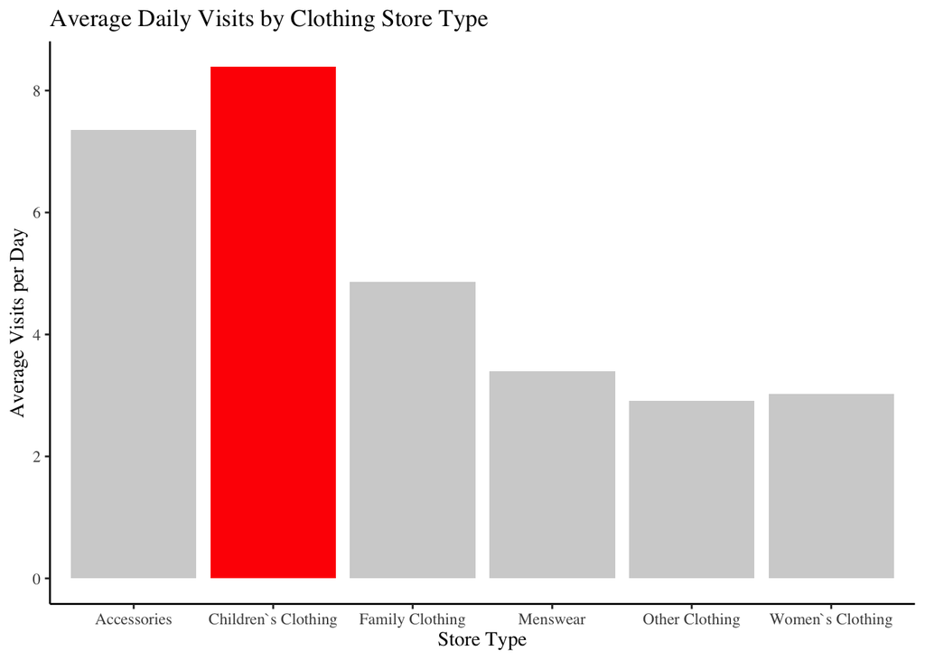

```r
library(gghighlight)
dailyvisitsClothing %>%
  mutate(naics_code = factor(naics_code)) %>%
  group_by(naics_code) %>%
  summarize(Avg_Visits_bd = mean(visits_by_day)) %>%
  ggplot(aes(x = naics_code, y=Avg_Visits_bd)) + geom_col(fill='red')+
  labs(x = 'Store Type', y = 'Average Visits per Day', title = 'Average Daily Visits by Clothing Store Type') +
  gghighlight(naics_code %in% c('Children`s Clothing'),
              unhighlighted_params = aes(size=.1),
              label_params=list(direction='y',nudge_x=10)) +
  theme_classic(base_family='serif')
```

# Origin of Children’s Clothing Store Visitors Next, I will take a look at the origin of the people who visit clothing stores to find a good location for the store. A good location would probably be close/in the neighborhood where most visitors live.

```r
library(tigris)
```

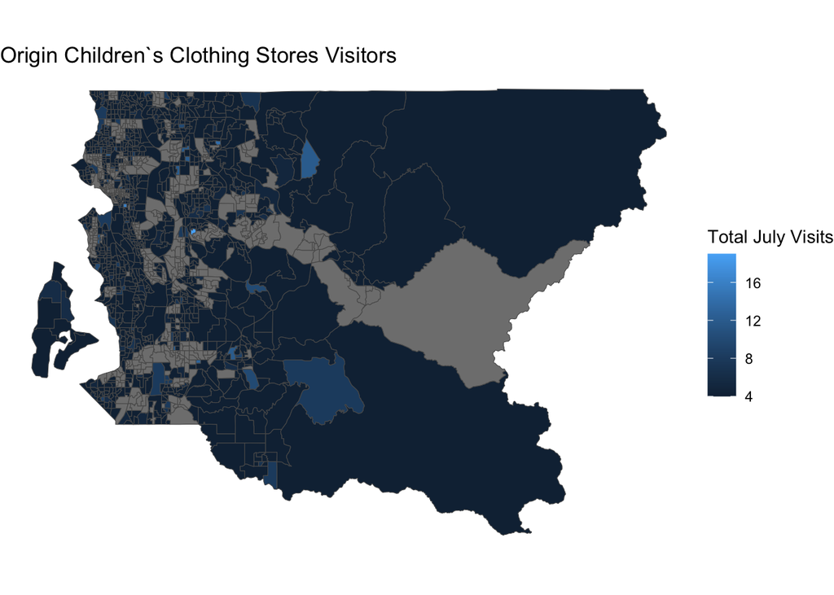

```r
mapdata <- block_groups('WA','033', cb = TRUE, progress_bar = FALSE)
ov2 <- ov %>%
  filter(naics_code %in% c(448130)) %>%
  group_by(GEOID) %>%
  summarise(visits = sum(visits))

map_and_data <- geo_join(mapdata, ov, by = 'GEOID', how = 'left')
ggplot(map_and_data) +
  geom_sf(aes(fill = visits)) +
  theme_void() +
  labs(fill = 'Total July Visits', title = 'Origin Children`s Clothing Stores Visitors')
```

Next, I will take a look at the Children’s Clothing brands that are most popular in King County.

Story: The most popular brands (brands with most visits) are The Children’s Place, Hanna Andersson, and Carter’s. However, The Children’s Place had by far the most total visits.

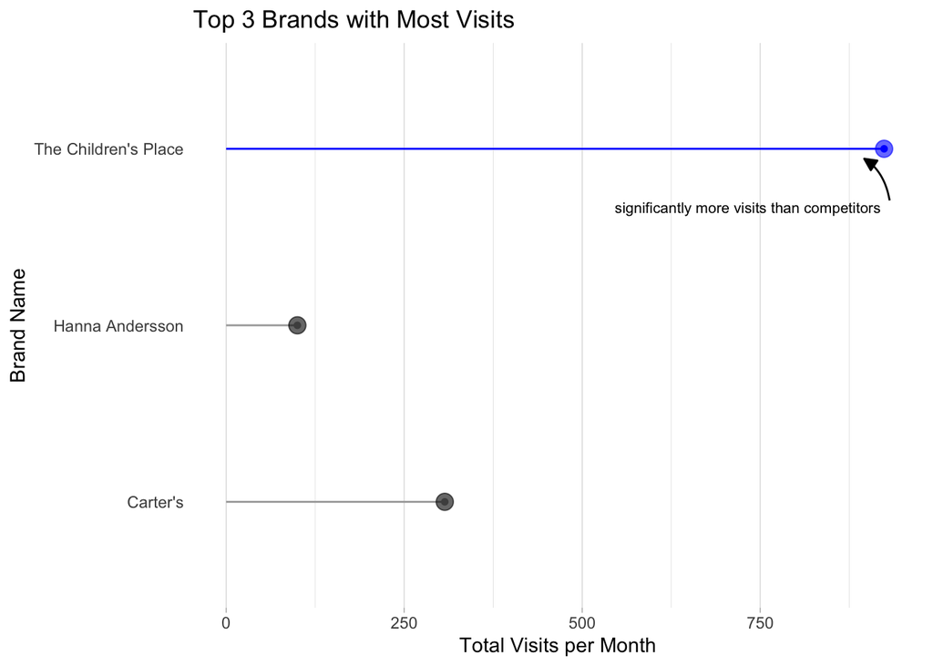

```r
#top 3 brands
ChildrensClothing <- dailyvisitsClothing %>%
  filter(dailyvisitsClothing$naics_code == 'Children`s Clothing')

top3brands = ChildrensClothing %>%
  group_by(brands) %>%
  summarise(totalVisits = sum(visits_by_day))%>%
  arrange(totalVisits) %>%
  slice(4:6)

top3brands %>%
ggplot(aes(x=totalVisits, y= brands)) +  geom_lollipop(horizontal=TRUE, col = c('darkgrey', 'darkgrey', 'blue')) +
  labs(x = 'Total Visits per Month', y = 'Brand Name', title = 'Top 3 Brands with Most Visits') +
  geom_point(col= c("black","black", "blue"), size=4, alpha=0.6) +
  theme_light() +
  theme(
    panel.grid.major.y = element_blank(),
    panel.border = element_blank(),
    axis.ticks.y = element_blank()
  )  +
  geom_text(data = data.frame(x = 732.719604182939, y = 2.66806116205063, label = "significantly more visits than competitors"),
mapping = aes(x = x, y = y, label = label),
size = 2.82, lineheight = 1L, inherit.aes = FALSE) +
  geom_curve(data = data.frame(x = 931.840806814783, y = 2.70746569798501, xend = 896.048336472378, yend = 2.9438929135913),
mapping = aes(x = x, y = y, xend = xend, yend = yend),
angle = 109L, curvature = 0.24, arrow = arrow(26L, unit(0.1, "inches"),
"last", "closed"),
inherit.aes = FALSE)
```

```r
TheChildrensPlace <- dv %>%
  filter(dv$brands == "The Children's Place")

TheChildrensPlace$date <- as.Date(TheChildrensPlace$date)

weekdays1 <- c('Monday', 'Tuesday', 'Wednesday', 'Thursday', 'Friday')

TheChildrensPlace$wDay <- factor((weekdays(TheChildrensPlace$date) %in% weekdays1),
         levels=c(FALSE, TRUE), labels=c('weekend', 'weekday'))
#To find the averages for pie chart
#TheChildrensPlace %>%
  #group_by(wDay) %>%
  #summarise(AvgVisits = mean(visits_by_day)) %>%
  #ggplot(aes(x = wDay, y= AvgVisits)) + geom_col()
```

Since the Children’s Place had by far the most visitors, I will analyse the dispersion of the visits by day of the brand “The Children’s Place” next.

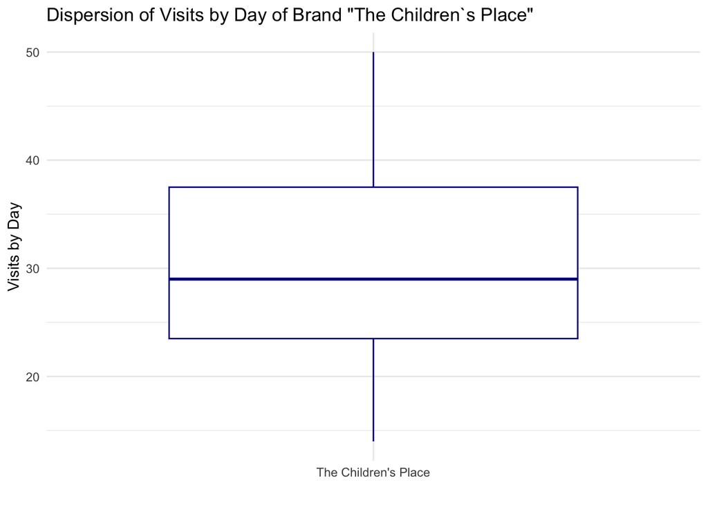

```r
TheChildrensPlace %>%
  ggplot(aes(x = brands, y = visits_by_day)) + geom_boxplot(col= 'darkblue') +
  labs(x = '', y = "Visits by Day", title = 'Dispersion of Visits by Day of Brand "The Children`s Place"') + theme_minimal()
```